# Decision Making Study

PSY 120L Reproducible Analysis Report

Author

Rachel Morrow

Published

June 7, 2026

## About This Report

##In order to examine the relationship between peer influence, and personality (specifically conscientiousness) on risk taking behavior, this study consists of a two way ANOVA.

## Study Overview

## The observed factors and levels are as follows

## IV: Peer norm exposure (avoid, engage)– priming statements

## Moderator: Conscientiousness (high, low)– median split of self report survey data

## DV1: Peer norm resistance level– self report survey data

## DV2: Risk taking propensity– self report survey data

## Setup and Software Environment

## Below are packages required to manipulate the data, create plots, construct scales and test them for reliability, and run ANOVA tests and collect relevant data from them (including effect, means, and confidence)

## Load Packages

```r
library(tidyverse)  # data manipulation + plotting
library(psych)      # scale construction + reliability
library(afex)       # ANOVA models + effect sizes
library(emmeans)    # estimated marginal means + confidence intervals
```

## Data Source and Analysis Dataset

##Here we input the data file from our survey

### Import Dataset

```r
study_raw <- read_csv("data/decision_making_data.csv")
```

### Check Imported Dataset

```r
dim(study_raw)
```

```
[1] 65 42
```

```r
names(study_raw)
```

```
 [1] "StartDate"             "EndDate"               "Status"
 [4] "IPAddress"             "Progress"              "Duration (in seconds)"
 [7] "Finished"              "RecordedDate"          "ResponseId"
[10] "ExternalReference"     "LocationLatitude"      "LocationLongitude"
[13] "DistributionChannel"   "UserLanguage"          "consent"
[16] "mc"                    "RTL_1"                 "RTL_2"
[19] "RTL_3"                 "RTL_4"                 "RTL_5"
[22] "PNR_1"                 "PNR_2"                 "PNR_3"
[25] "PNR_4"                 "PNR_5"                 "con_1"
[28] "con_2"                 "con_3"                 "con_4"
[31] "con_5"                 "con_6"                 "con_7"
[34] "con_8"                 "con_9"                 "con_10"
[37] "con_11"                "con_12"                "age"
[40] "academic_year"         "gender"                "condition"
```

```r
head(study_raw)
```

```
# A tibble: 6 × 42
  StartDate    EndDate Status IPAddress Progress Duration (in seconds…¹ Finished
  <chr>        <chr>    <dbl> <chr>        <dbl>                  <dbl>    <dbl>
1 5/5/26 20:03 5/5/26…      0 72.205.8…      100                    146        1
2 5/6/26 10:41 5/6/26…      0 169.231.…      100                    298        1
3 5/6/26 14:03 5/6/26…      0 169.231.…      100                    874        1
4 5/6/26 15:03 5/6/26…      0 169.231.…      100                    211        1
5 5/5/26 19:04 5/6/26…      0 68.6.116…      100                  83227        1
6 5/6/26 22:11 5/6/26…      0 184.187.…      100                    261        1
# ℹ abbreviated name: ¹`Duration (in seconds)`
# ℹ 35 more variables: RecordedDate <chr>, ResponseId <chr>,
#   ExternalReference <lgl>, LocationLatitude <dbl>, LocationLongitude <dbl>,
#   DistributionChannel <chr>, UserLanguage <chr>, consent <dbl>, mc <dbl>,
#   RTL_1 <dbl>, RTL_2 <dbl>, RTL_3 <dbl>, RTL_4 <dbl>, RTL_5 <dbl>,
#   PNR_1 <dbl>, PNR_2 <dbl>, PNR_3 <dbl>, PNR_4 <dbl>, PNR_5 <dbl>,
#   con_1 <dbl>, con_2 <dbl>, con_3 <dbl>, con_4 <dbl>, con_5 <dbl>, …
```

## The above data depicts the names of each element and question of the survey, and on the second page,

## the day the survey was taken and the length of time the first 6 participants alotted to complete the survey.

### Create Analysis Dataset

```r
study_vars <- c(
  "condition",  # experimental condition variable
  "age", "academic_year", "gender",

          "RTL_1", "RTL_2", "RTL_3", "RTL_4", "RTL_5",

          "PNR_1", "PNR_2", "PNR_3", "PNR_4", "PNR_5",

          "con_1", "con_2", "con_3", "con_4", "con_5",
          "con_6", "con_7", "con_8", "con_9", "con_10",
          "con_11", "con_12"
)

study_data <- study_raw %>%
  select(all_of(study_vars)) %>%
  mutate(across(everything(), as.numeric))
```

### Check Analysis Dataset

```r
length(study_vars)
```

```
[1] 26
```

```r
dim(study_data)
```

```
[1] 65 26
```

```r
names(study_data)
```

```
 [1] "condition"     "age"           "academic_year" "gender"
 [5] "RTL_1"         "RTL_2"         "RTL_3"         "RTL_4"
 [9] "RTL_5"         "PNR_1"         "PNR_2"         "PNR_3"
[13] "PNR_4"         "PNR_5"         "con_1"         "con_2"
[17] "con_3"         "con_4"         "con_5"         "con_6"
[21] "con_7"         "con_8"         "con_9"         "con_10"
[25] "con_11"        "con_12"
```

## We changed the elements to numeric data

## There were 65 responses

## 65 rows and 26 columns (items)

## Variable Preparation

### Prepare Participant ID and Experimental Condition

```r
study_data <- study_data %>%
  mutate(
    id = row_number(),
    condition= factor(
      condition,
      levels = c(0, 1),
      labels = c("Risk-Avoiding", "Risk-Normalizing")
    )
  )
```

## Risk avoiding is now 0, and normalizing is 1

### Check Experimental Condition Coding

```r
study_data %>%
  count(condition) %>%
  knitr::kable(
    col.names = c("Condition", "n")
  )
```

| Condition | n |
| --- | --- |
| Risk-Avoiding | 31 |
| Risk-Normalizing | 33 |
| NA | 1 |

##The condition check confirms the number of participants assigned to each risk-priming condition.

### Check Prepared Analysis Dataset

```r
dim(study_data)
```

```
[1] 65 27
```

```r
names(study_data)
```

```
 [1] "condition"     "age"           "academic_year" "gender"
 [5] "RTL_1"         "RTL_2"         "RTL_3"         "RTL_4"
 [9] "RTL_5"         "PNR_1"         "PNR_2"         "PNR_3"
[13] "PNR_4"         "PNR_5"         "con_1"         "con_2"
[17] "con_3"         "con_4"         "con_5"         "con_6"
[21] "con_7"         "con_8"         "con_9"         "con_10"
[25] "con_11"        "con_12"        "id"
```

## After checking for the distribution of participants in each condition (which was mostly even), the dataset is presented again with names for each question/ factor and dimensions for the table

## RTL: Risk Taking Likelihood

## PNR: Peer Norm Resistance

## Con: Conscientiousness

### Reverse-Code Scale Items

### To check for response validity, half of the items on the conscientiousness scale were reverse scored (would indicate less contientiousness) and need to be switched in terms of value.

```r
study_data <- study_data %>%
  mutate(
    con_1r = 6 - con_1,
    con_2r = 6 - con_2,
    con_5r = 6 - con_5,
    con_6r = 6 - con_6,
    con_10r = 6 - con_10,
    con_12r = 6 - con_12
  )
```

### Check Reverse Coding

```r
study_data %>%
  select(con_1, con_1r) %>%
  head(10) %>%
  knitr::kable()
```

| con_1 | con_1r |
| --- | --- |
| 4 | 2 |
| 1 | 5 |
| 1 | 5 |
| 1 | 5 |
| 2 | 4 |
| 4 | 2 |
| 2 | 4 |
| 1 | 5 |
| 2 | 4 |
| 2 | 4 |

## The response values on the contientiousness scale which were reverse scored for validity have been changed to the opposite value

### Create Scale Scores

## Now that the data values are all prepared correctly, we organize each survey item by their scale/ variable in the study.

```r
# Define risk-taking likelihood items
risk_taking_items <- c("RTL_1", "RTL_2", "RTL_3", "RTL_4", "RTL_5")

# Define peer norm resistance items
peer_norm_resistance_items <- c("PNR_1", "PNR_2", "PNR_3", "PNR_4", "PNR_5")

# Define conscientiousness items
conscientiousness_items <- c("con_1r", "con_2r", "con_3", "con_4", "con_5r", "con_6r", "con_7", "con_8", "con_9", "con_10r", "con_11", "con_12r")

# Create scale scores
study_data <- study_data %>%
  mutate(
    risk_taking = rowMeans(across(all_of(risk_taking_items)), na.rm = TRUE),
    peer_norm_resistance = rowMeans(across(all_of(peer_norm_resistance_items)), na.rm = TRUE),
    conscientiousness = rowMeans(across(all_of(conscientiousness_items)), na.rm = TRUE)
  )
```

### Check Scale Scores

```r
study_data %>%
  select(risk_taking, peer_norm_resistance, conscientiousness) %>%
  summary()
```

```
  risk_taking   peer_norm_resistance conscientiousness
 Min.   :1.00   Min.   :3.400        Min.   :2.333
 1st Qu.:2.20   1st Qu.:5.000        1st Qu.:3.250
 Median :2.80   Median :6.000        Median :3.667
 Mean   :2.84   Mean   :5.698        Mean   :3.614
 3rd Qu.:3.40   3rd Qu.:6.400        3rd Qu.:3.917
 Max.   :5.60   Max.   :7.000        Max.   :4.833
```

```r
study_data %>%
  summarise(
    risk_taking_missing = mean(is.na(risk_taking)),
    peer_norm_resistance_missing = mean(is.na(peer_norm_resistance)),
    conscientiousness_missing = mean(is.na(conscientiousness))
  ) %>%
  knitr::kable()
```

| risk_taking_missing | peer_norm_resistance_missing | conscientiousness_missing |
| --- | --- | --- |
| 0 | 0 | 0 |

##Now that the data has been organized for the variables of RT, PNR, and CON, we see the distribution of the data.

### Create Concientiousness Groups

##Because conscientiousness was a continuous variable, we create a median split to create high and low conscientiousness groups.

```r
conscientiousness_median <- median(study_data$conscientiousness, na.rm = TRUE)

study_data <- study_data %>%
  mutate(
    conscientiousness_msplit = if_else(conscientiousness <= conscientiousness_median, "Low", "High"),
    conscientiousness_msplit = factor(conscientiousness_msplit, levels = c("Low", "High"))
  )

conscientiousness_median
```

```
[1] 3.666667
```

```r
study_data %>%
  count(conscientiousness_msplit) %>%
  knitr::kable()
```

| conscientiousness_msplit | n |
| --- | --- |
| Low | 35 |
| High | 30 |

### Check Scale Reliability

##To check this scale for reliability, we use Cronbach’s alpha and McDonald’s Omega:

```r
risk_taking_item_df <- study_data %>% select(all_of(risk_taking_items))
peer_norm_resistance_item_df <- study_data %>% select(all_of(peer_norm_resistance_items))
conscientiousness_item_df <- study_data %>% select(all_of(conscientiousness_items))

risk_taking_alpha <- psych::alpha(risk_taking_item_df)
```

```
Some items ( RTL_5 ) were negatively correlated with the first principal component and
probably should be reversed.
To do this, run the function again with the 'check.keys=TRUE' option
```

```r
risk_taking_omega <- psych::omega(risk_taking_item_df, plot = FALSE)

peer_norm_resistance_alpha <- psych::alpha(peer_norm_resistance_item_df)
peer_norm_resistance_omega <- psych::omega(peer_norm_resistance_item_df, plot = FALSE)

conscientiousness_alpha <- psych::alpha(conscientiousness_item_df)
conscientiousness_omega <- psych::omega(conscientiousness_item_df, plot = FALSE)

reliability_table <- tibble(
  scale = c("Risk-Taking Likelihood", "Peer Norm Resistance", "Conscientiousness"),
  alpha = c(
    risk_taking_alpha$total$raw_alpha,
    peer_norm_resistance_alpha$total$raw_alpha,
    conscientiousness_alpha$total$raw_alpha
  ),
  omega = c(
    risk_taking_omega$omega.tot,
    peer_norm_resistance_omega$omega.tot,
    conscientiousness_omega$omega.tot
  )
)

reliability_table %>%
  mutate(
    alpha = round(alpha, 2),
    omega = round(omega, 2)
  ) %>%
  knitr::kable(
    col.names = c("Scale", "Cronbach's alpha", "McDonald's omega")
  )
```

| Scale | Cronbach’s alpha | McDonald’s omega |
| --- | --- | --- |
| Risk-Taking Likelihood | 0.37 | 0.46 |
| Peer Norm Resistance | 0.82 | 0.89 |
| Conscientiousness | 0.77 | 0.84 |

## RTL is low on both Cronbach’s alpha and McDonald’s omega, indicating low scale reliability

## This may be due to the items on this scale– The range of activities which participants were asked about was wide, from minorly risky activities to life-threatening ones. Since all items were scored the same despite this limitation, the responses were too varied to be reliable.

## Descriptive Statistics

## For each variable, values of mean, standard deviation, mean absolute deviation, minimum, maximum, skew, distribution on the tails, and standard error are calculated.

### Scale Score Descriptives

```r
study_data %>%
  select(risk_taking, peer_norm_resistance, conscientiousness) %>%
  psych::describe() %>%
  knitr::kable(digits = 2)
```

|  | vars | n | mean | sd | median | trimmed | mad | min | max | range | skew | kurtosis | se |
| --- | --- | --- | --- | --- | --- | --- | --- | --- | --- | --- | --- | --- | --- |
| risk_taking | 1 | 65 | 2.84 | 1.00 | 2.80 | 2.78 | 0.89 | 1.00 | 5.60 | 4.6 | 0.56 | -0.14 | 0.12 |
| peer_norm_resistance | 2 | 65 | 5.70 | 0.93 | 6.00 | 5.76 | 0.89 | 3.40 | 7.00 | 3.6 | -0.53 | -0.39 | 0.12 |
| conscientiousness | 3 | 65 | 3.61 | 0.56 | 3.67 | 3.61 | 0.49 | 2.33 | 4.83 | 2.5 | -0.04 | -0.52 | 0.07 |

### Sample Composition

```r
study_data %>%
  summarise(
    mean_age = mean(age, na.rm = TRUE),
    sd_age = sd(age, na.rm = TRUE),
    min_age = min(age, na.rm = TRUE),
    max_age = max(age, na.rm = TRUE)
  ) %>%
  knitr::kable(digits = 2)
```

| mean_age | sd_age | min_age | max_age |
| --- | --- | --- | --- |
| 21.65 | 3.37 | 18 | 45 |

```r
study_data %>%
  count(academic_year) %>%
  mutate(percent = round(100 * n / sum(n), 1)) %>%
  knitr::kable()
```

| academic_year | n | percent |
| --- | --- | --- |
| 1 | 4 | 6.2 |
| 2 | 6 | 9.2 |
| 3 | 14 | 21.5 |
| 4 | 38 | 58.5 |
| 5 | 3 | 4.6 |

```r
study_data %>%
  count(gender) %>%
  mutate(percent = round(100 * n / sum(n), 1)) %>%
  knitr::kable()
```

| gender | n | percent |
| --- | --- | --- |
| 1 | 14 | 21.5 |
| 2 | 50 | 76.9 |
| 4 | 1 | 1.5 |

## The above tables describe the distribution for each demographic category

## gender 1: male, gender 2: female, gender 4: non-binary

## Correlations Among the DVs

## We have 2 DVs in our study (risk taking and peer norm resistance), the following tests check to see if they are correlated with each other (or to what extent)

```r
study_data %>%
  select(risk_taking, peer_norm_resistance) %>%
  psych::corr.test()
```

```
Call:psych::corr.test(x = .)
Correlation matrix
                     risk_taking peer_norm_resistance
risk_taking                 1.00                -0.25
peer_norm_resistance       -0.25                 1.00
Sample Size
[1] 65
Probability values (Entries above the diagonal are adjusted for multiple tests.)
                     risk_taking peer_norm_resistance
risk_taking                 0.00                 0.05
peer_norm_resistance        0.05                 0.00

 To see confidence intervals of the correlations, print with the short=FALSE option
```

## Primary Analyses

## There is a weak negative correlation between risk taking likelihood (RTL) and peer norm resistance (PNR)– As RTL is high, PNR is low (meaning that participants who do not resist peer norms are more likely to take risks)

## ## This test, however, is not statistically significant– the p-value is .05, and not under (although it is close)

### Risk Taking Model

### The following is a correlational analysis of risk-taking per the DOSPERT scale– the median split of high and low conscientiousness creates the two conditions, and here we will see how they differ on the DV.

```r
a1_risk <- afex::aov_ez(
  id = "id",
  dv = "risk_taking",
  between = c("condition", "conscientiousness_msplit"),
  data = study_data
)

a1_risk
```

```
Anova Table (Type 3 tests)

Response: risk_taking
                              Effect    df  MSE      F   ges p.value
1                          condition 1, 60 0.93 4.55 *  .070    .037
2           conscientiousness_msplit 1, 60 0.93 3.41 +  .054    .070
3 condition:conscientiousness_msplit 1, 60 0.93   0.01 <.001    .931
---
Signif. codes:  0 '***' 0.001 '**' 0.01 '*' 0.05 '+' 0.1 ' ' 1
```

## The only significant test in this table was “condition 1,” describing the result of only the priming condition on the risk-taking likelihood.

## Conscientiousness independently yeilded no significant effect on risk-taking likelihood, and neither did the interaction of conscientiousness of the two.

### Estimated Means for Risk Taking:

```r
emmeans(a1_risk, ~ condition)
```

```
 condition        emmean    SE df lower.CL upper.CL
 Risk-Avoiding      3.06 0.174 60     2.72     3.41
 Risk-Normalizing   2.54 0.172 60     2.20     2.89

Results are averaged over the levels of: conscientiousness_msplit
Confidence level used: 0.95
```

```r
emmeans(a1_risk, ~ conscientiousness_msplit)
```

```
 conscientiousness_msplit emmean    SE df lower.CL upper.CL
 Low                        3.03 0.165 60     2.70     3.36
 High                       2.58 0.180 60     2.22     2.94

Results are averaged over the levels of: condition
Confidence level used: 0.95
```

```r
emmeans(a1_risk, ~ condition * conscientiousness_msplit)
```

```
 condition        conscientiousness_msplit emmean    SE df lower.CL upper.CL
 Risk-Avoiding    Low                        3.28 0.249 60     2.78     3.78
 Risk-Normalizing Low                        2.78 0.216 60     2.35     3.21
 Risk-Avoiding    High                       2.85 0.241 60     2.37     3.33
 Risk-Normalizing High                       2.31 0.268 60     1.77     2.84

Confidence level used: 0.95
```

## Confidence level is close to 1– high

## For each IV condition, participants are divided on the moderating variable (conscientiousness) with a median split

### Peer Norm Resistance Model

##As we did for the conscientiousness variable, we run a correlational test for DV1(Peer-norm resistance), to compare any effects due to conscientiousness, peer-norm resistance, or the interaction between the two.

```r
a1_peer <- afex::aov_ez(
  id = "id",
  dv = "peer_norm_resistance",
  between = c("condition", "conscientiousness_msplit"),
  data = study_data
)

a1_peer
```

```
Anova Table (Type 3 tests)

Response: peer_norm_resistance
                              Effect    df  MSE    F  ges p.value
1                          condition 1, 60 0.76 1.51 .025    .224
2           conscientiousness_msplit 1, 60 0.76 2.49 .040    .120
3 condition:conscientiousness_msplit 1, 60 0.76 2.34 .038    .131
---
Signif. codes:  0 '***' 0.001 '**' 0.01 '*' 0.05 '+' 0.1 ' ' 1
```

## Condition 1 (priming) had no significant effect on PNR, and it neither did on conscientiousness (as we saw previously). Likewise, there was no interaction effect between the two.

### Estimated Means for Peer Norm Resistance

```r
emmeans(a1_peer, ~ condition)
```

```
 condition        emmean    SE df lower.CL upper.CL
 Risk-Avoiding      5.63 0.157 60     5.32     5.95
 Risk-Normalizing   5.90 0.155 60     5.59     6.21

Results are averaged over the levels of: conscientiousness_msplit
Confidence level used: 0.95
```

```r
emmeans(a1_peer, ~ conscientiousness_msplit)
```

```
 conscientiousness_msplit emmean    SE df lower.CL upper.CL
 Low                        5.59 0.149 60     5.30     5.89
 High                       5.94 0.163 60     5.62     6.27

Results are averaged over the levels of: condition
Confidence level used: 0.95
```

```r
emmeans(a1_peer, ~ condition * conscientiousness_msplit)
```

```
 condition        conscientiousness_msplit emmean    SE df lower.CL upper.CL
 Risk-Avoiding    Low                        5.63 0.225 60     5.18     6.08
 Risk-Normalizing Low                        5.56 0.195 60     5.17     5.95
 Risk-Avoiding    High                       5.64 0.218 60     5.20     6.07
 Risk-Normalizing High                       6.25 0.242 60     5.76     6.73

Confidence level used: 0.95
```

## Figures

## The following are data visualizations of the previous correlational tests.

### Risk-taking Interaction Plot

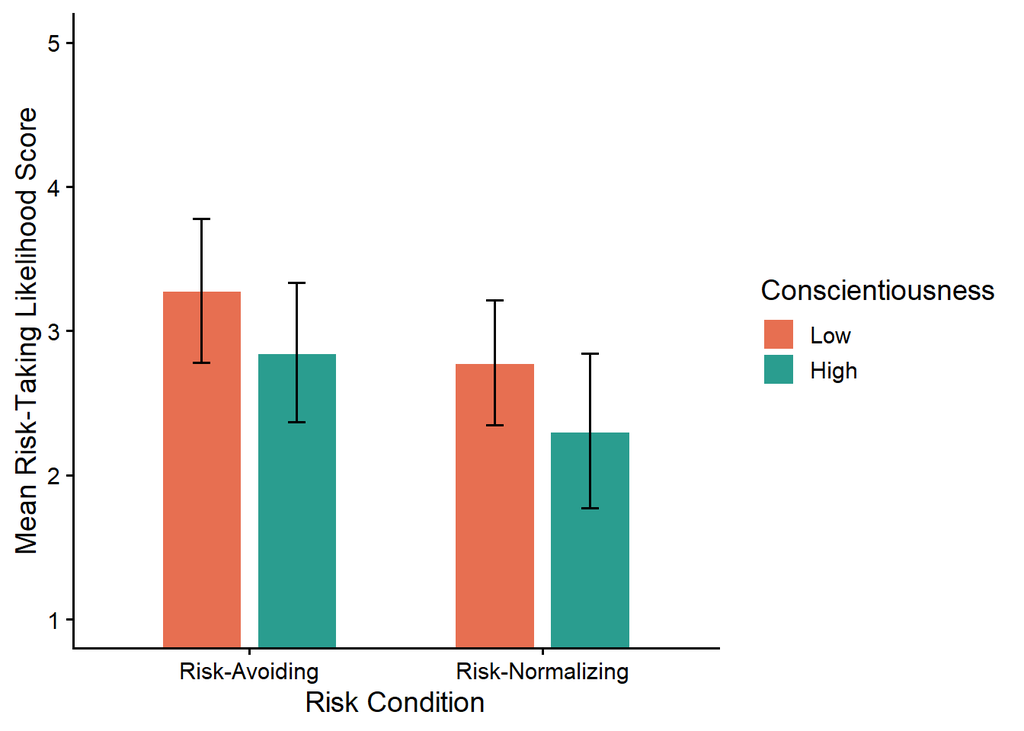

```r
risk_cell_means <- as.data.frame(
  emmeans(a1_risk, ~ condition * conscientiousness_msplit)
)

p_risk_bar <- ggplot(
  risk_cell_means,
  aes(
    x = condition,
    y = emmean,
    fill = conscientiousness_msplit
  )
) +
  geom_col(
    position = position_dodge(width = 0.65),
    width = 0.55,
    color = "white"
  ) +
  geom_errorbar(
    aes(
      ymin = lower.CL,
      ymax = upper.CL
    ),
    position = position_dodge(width = 0.65),
    width = 0.12,
    linewidth = 0.7
  ) +
  labs(
    x = "Risk Condition",
    y = "Mean Risk-Taking Likelihood Score",
    fill = "Conscientiousness"
  ) +
  scale_fill_manual(
    values = c(
      "Low" = "#E76F51",  # YOU CAN CHANGE THESE TWO HEX VALUES TO MATCH YOUR POSTER!
      "High" = "#2A9D8F"  # YOU CAN CHANGE THESE TWO HEX VALUES TO MATCH YOUR POSTER!
    )
  ) +
  scale_y_continuous(breaks = 1:5) +
  coord_cartesian(ylim = c(1, 5)) +
  theme_classic(base_size = 14)

p_risk_bar
```